# Clip Challenge

##### Daniel Urencio Álvarez

```python
# Core libraries
import pandas as pd
import numpy as np
import matplotlib.pyplot as plt
import colorcet as cc

# Chart utilities
from bokeh.plotting import figure, output_file, show
from bokeh.models import ColumnDataSource, SingleIntervalTicker, LinearAxis, FixedTicker, PrintfTickFormatter
from bokeh.palettes import Spectral3
from bokeh.io import output_notebook
from bokeh.palettes import Category20c, GnBu3, OrRd3, Spectral5, Spectral6
from bokeh.transform import cumsum as cumsum_, factor_cmap
from bokeh.core.properties import value
from bokeh.models.formatters import DatetimeTickFormatter

# Statistics & math
from sqlalchemy import create_engine
from statsmodels.tsa.seasonal import seasonal_decompose
from collections import OrderedDict
from scipy.stats.kde import gaussian_kde
from math import pi
from numpy import linspace

# Turn warnings off
import warnings
warnings.filterwarnings('ignore')
```

## 1. You were tasked with creating a report on Clips retention rates. We calculate individual cohort retention as follows:

The first transaction of a merchant becomes their cohort month. For example, if merchant A has their first transaction on Feb 12th, 2017 then their cohort would be February.

### a. Please create a mock transaction table and provide the SQL code you would use to calculate monthly cohort retention rates.

```python
# Create connection to SQL database:
conn = create_engine('postgresql://daniel:123123@localhost/daniel')
```

```python
# Retrieve data from DB:
mock_transactions = pd.read_sql('select * from transactions',conn)
```

```python
# Show the first 5 rows of the mock table:
mock_transactions.head(5)
```

|  | merchant_id | created_at | transaction |
| --- | --- | --- | --- |
| 0 | 77 | 2018-05-28 | 66.18 |
| 1 | 75 | 2016-10-06 | 75.53 |
| 2 | 38 | 2018-05-29 | 2.76 |
| 3 | 45 | 2018-08-15 | 10.09 |
| 4 | 55 | 2016-12-04 | 45.95 |

```
---------------------------------------------
-- RETENTION RATES by COHORT GROUPS
---------------------------------------------

with trans as (
        select
                cohort_month,
                transaction_date,
                count(distinct merchant_id) as users
        from (
                select
                        Merchant_id,
                        created_at,
                        date_trunc('month',created_at) as transaction_date,
                        min(date_trunc('month',created_at)) over (Partition by Merchant_id) as cohort_month
                From (select * from transactions order by merchant_id,created_at) as t_
                order by merchant_id
        ) as foo
        group by
                cohort_month,
                transaction_date
)
select
        a.cohort_month,
        a.transaction_date,
        (cast(a.users as decimal) / b.users)*100 as retention_rate
from trans a
left join (
        select
                cohort_month,
                users
        from trans
        where
                cohort_month = transaction_date
) b
on a.cohort_month = b.cohort_month;
```

```python
query =\
'''
    with trans as (
            select
                    cohort_month,
                    transaction_date,
                    count(distinct merchant_id) as users
            from (
                    select
                            Merchant_id,
                            created_at,
                            date_trunc('month',created_at) as transaction_date,
                            min(date_trunc('month',created_at)) over (Partition by Merchant_id) as cohort_month
                    From (select * from transactions order by merchant_id,created_at) as t_
                    order by merchant_id
            ) as foo
            group by
                    cohort_month,
                    transaction_date
    )
    select
            a.cohort_month,
            a.transaction_date,
            (cast(a.users as decimal) / b.users)*100 as retention_rate
    from trans a
    left join (
            select
                    cohort_month,
                    users
            from trans
            where
                    cohort_month = transaction_date
    ) b
    on a.cohort_month = b.cohort_month;
'''
```

```python
query_result = pd.read_sql(query,conn)
```

```python
query_result.head(5)
```

|  | cohort_month | transaction_date | retention_rate |
| --- | --- | --- | --- |
| 0 | 2016-01-01 00:00:00-06:00 | 2016-01-01 00:00:00-06:00 | 100.0 |
| 1 | 2016-01-01 00:00:00-06:00 | 2016-02-01 00:00:00-06:00 | 45.0 |
| 2 | 2016-01-01 00:00:00-06:00 | 2016-03-01 00:00:00-06:00 | 75.0 |
| 3 | 2016-01-01 00:00:00-06:00 | 2016-04-01 00:00:00-06:00 | 80.0 |
| 4 | 2016-01-01 00:00:00-06:00 | 2016-05-01 00:00:00-05:00 | 80.0 |

### b. After completing the cohort retention analysis, please provide the SQL code to calculate the overall retention curve

(which will include data from all cohorts in existence)

```
---------------------------------------------
-- OVERALL RETENTION RATE
---------------------------------------------

with overall as (
        select
                row_number() over () as row_n,
                *
        from (
                select
                        cast('1' as int) as ix,
                        date_trunc('month',created_at) as transaction_date,
                        count(distinct merchant_id) as users
                from transactions
                group by
                        transaction_date
                order by
                        transaction_date
        ) as temp
)
select
        a.transaction_date,
        (cast(a.users as decimal) / b.users) * 100 as overall_retention
from overall a
left join (select * from overall where row_n = ix) as b
on a.ix = b.ix;
```

```python
query = '''
    with overall as (
            select
                    row_number() over () as row_n,
                    *
            from (
                    select
                            cast('1' as int) as ix,
                            date_trunc('month',created_at) as transaction_date,
                            count(distinct merchant_id) as users
                    from transactions
                    group by
                            transaction_date
                    order by
                            transaction_date
            ) as temp
    )
    select
            a.transaction_date,
            (cast(a.users as decimal) / b.users) * 100 as overall_retention
    from overall a
    left join (select * from overall where row_n = ix) as b
    on a.ix = b.ix
'''
```

```python
query_result = pd.read_sql(query,conn)
```

```python
query_result.head(5)
```

|  | transaction_date | overall_retention |
| --- | --- | --- |
| 0 | 2016-01-01 00:00:00-06:00 | 100.00 |
| 1 | 2016-02-01 00:00:00-06:00 | 61.25 |
| 2 | 2016-03-01 00:00:00-06:00 | 91.25 |
| 3 | 2016-04-01 00:00:00-06:00 | 101.25 |
| 4 | 2016-05-01 00:00:00-05:00 | 93.75 |

## **2. You were asked to create a chart showing our gross income compared to our yearly goal. You find that our current gross income is \$3.6 Billion and it is May 21, our yearly goal is \$15.3 Billion.**

For this answer I have prepared a mock table. The following code lines show its structure (units are in billion).

```python
gross_income = pd.read_csv('gross_income_.csv',parse_dates=['date'])
gross_income['cum_sum'] = gross_income['gross_income'].cumsum()
gross_income['diff'] = 15.3 - gross_income.cum_sum
```

```python
gross_income.head()
```

|  | date | gross_income | cum_sum | diff |
| --- | --- | --- | --- | --- |
| 0 | 2016-11-28 | 0.082741 | 0.082741 | 15.217259 |
| 1 | 2016-12-05 | 0.052896 | 0.135637 | 15.164363 |
| 2 | 2016-12-12 | 0.088747 | 0.224384 | 15.075616 |
| 3 | 2016-12-19 | 0.068774 | 0.293158 | 15.006842 |
| 4 | 2016-12-26 | 0.039936 | 0.333094 | 14.966906 |

```python
# Set data
cumsum = gross_income['cum_sum'].astype(float).values
diff = gross_income['diff'].astype(float).values
stacks = OrderedDict(cumsum=cumsum, diff=diff)

dates = gross_income.date.dt.strftime('%Y-%m-%d').tolist()
categories = ["cumsum", "diff"]
colors = ["#718dbf", "#e84d60"]

data = {
        'dates': dates,
        'cumsum': cumsum,
        'diff': diff,
        }

# Create the chart
p = figure(x_range=dates, plot_height=400, plot_width=950, title="Place the mouse on the bars to display the information",
           toolbar_location=None, tools="",
           tooltips='@dates<br><b>Income so far:</b> $@cumsum <br> <b>Distance to goal: </b>$@diff')

p.vbar_stack(categories, x='dates', width=0.9, color=colors, source=data,
             legend=['Cumulative gross income','Distance to goal'])

# Configure the chart
p.y_range.start = 0
p.x_range.range_padding = 0.1
p.xgrid.grid_line_color = None
p.axis.minor_tick_line_color = None
p.outline_line_color = None
p.legend.location = "top_left"
p.legend.orientation = "horizontal"

p.xaxis.visible = False
p.xaxis.major_label_orientation = "vertical"
p.xaxis.subgroup_label_orientation = "normal"
p.xaxis.group_label_orientation = 0.8
p.yaxis.axis_label = "$ Billion"
p.xaxis.axis_label = "Date"


p.legend.spacing = 10
p.legend.margin = 50
p.legend.label_standoff = 5

output_notebook();

show(p)
```

[interactive chart not shown]

### a. What is an immediate conclusion that you can see with this finding?

We would have achieved less than a quarter of the yearly goal within the fifth month of the year. In other words, at this point, assuming a constant monthly rate, we would end the year with roughly $8.7 Billion; this means we would be behind the goal by approximately 43% at the end of the year.

### b. After your discovery you want to provide the company with more insight, what are some of the ideas and steps you would take to gain more insight?

I would like to observe how the gross income has behaved during the past on a monthly or weekly basis. The motivation behind this is to provide a time-series decomposition analysis in order to answer the following questions:

1. Is there a clearly identifiable trend? If there is, is it a positive or a negative one and how pronounced is it?
2. Do data displays seasonal effects? In other words, do we see a cyclical pattern in which observations exhibit higher or lower values according to certain seasons?
3. And lastly, can either the trend or the seasonal components be explained in term of other variables? Could this information be harnessed in terms of strategy and planning so that the yearly goal can be met?

### c. Choose one of your ideas and show me how you would implement it in SQL, Python, R or a language of your choosing. Please create mock tables and provide an outline of the data that could be found in your tables, also provide a chart or graph of how you’d present and visualize the data.

What a time-series decomposition pretends to achieve is to translate an observed time-oriented signal into an equation such as:

$$ Y_t = T_t + S_t + R_t $$

Where $Y_t$ corresponds to the observed signal; $T_t$, $S_t$ and $R_t$ represent the trend, seasonal and residual components respectively. Residuals are a portion of the observed value that can not be attributed to nor trend or seasons.

Since we are dealing with a summation of components what we want to obtain is **an additive time-series decomposition model**. In the following lines of code I am going to implement this kind of model using python.

```python
# Let's show the first 5 rows:
gross_income.head(5)
```

|  | date | gross_income | cum_sum | diff |
| --- | --- | --- | --- | --- |
| 0 | 2016-11-28 | 0.082741 | 0.082741 | 15.217259 |
| 1 | 2016-12-05 | 0.052896 | 0.135637 | 15.164363 |
| 2 | 2016-12-12 | 0.088747 | 0.224384 | 15.075616 |
| 3 | 2016-12-19 | 0.068774 | 0.293158 | 15.006842 |
| 4 | 2016-12-26 | 0.039936 | 0.333094 | 14.966906 |

*What we have in this table is the weekly gross income in billion, the cumulative sum and the difference between each week's cumulative quantity and the yearly goal. In order to visualize the data, consider the following code lines.*

```python
source = ColumnDataSource(gross_income)

p = figure(x_axis_type='datetime',plot_width=950,plot_height=400)
p.line(x='date', y='gross_income', line_width=1.5, source=source)

show(p)
```

[interactive chart not shown]

To decompose the series into trend, seasonal and residual factors we can do the following:

```python
serie = gross_income.set_index('date').gross_income
```

```python
decomposition = seasonal_decompose(x=serie,model='additive',freq=4*3)
trend = decomposition.trend
seasonal = decomposition.seasonal
residual = decomposition.resid
```

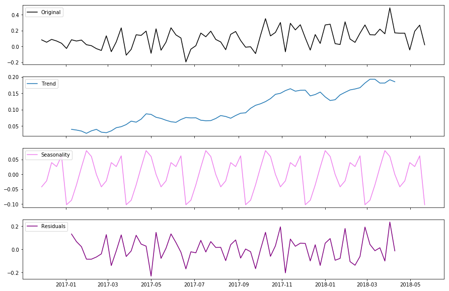

```python
fig, axes = plt.subplots(4, 1, sharex=True, sharey=False)
fig.set_figheight(10)
fig.set_figwidth(15)

axes[0].plot(serie, 'k', label='Original')
axes[0].legend(loc='upper left');

axes[1].plot(trend, label='Trend')
axes[1].legend(loc='upper left');

axes[2].plot(seasonal, 'violet', label='Seasonality')
axes[2].legend(loc='upper left');

axes[3].plot(residual, 'purple', label='Residuals')
axes[3].legend(loc='upper left')
```

The decomposition shows that there is clearly a seasonality factor in our data. This kind of insights might be very useful given that low-income periods are an opportunity to test new projects, products or strategies in order to reduce the pronunciation between weak and strong seasons.

Furthermore, there is also a positive trend. Some questions that naturally arise from this analysis are:

- What causes the seasonality?
- Could the trend's slope become more pronounced to accelerate the income's pace?
- What other information could be correlated to the observed weekly income? Do we possess that information? If not, how costly it is to gather it?

## 3. You are put in charge of creating metrics for a customer facing BI tool, in this case, the customers are merchants that transact with Clip.

### a. Please provide 5 metrics that you would present to the merchants on the BI tool. Please provide specific business use cases (from the perspective of the merchant) for each metric you choose.

### b. For all the metrics you present also provide appropriate charts or graphs. This is your opportunity to show your creative side as well as an understanding of business needs.

#### 1. Time distribution of sold products per day

```python
products = ['Black coffe','Cappucino','Espresso','Ham sandwich','Egg sandwich','Fruit bowl','Orange juice','Milk','Cake','Newspaper','Magazine', 'Cup Cake', 'Black tea','Chai tea','Ice tea']
```

```python
df_dict = { p:[ np.random.normal(np.random.randint(max(j,9),max(j+1,np.random.randint(12,19))),.5) for i in range(100) ] for j,p in enumerate(products) }
products_frequency = pd.DataFrame(df_dict)
```

```python
def ridge(category, data, scale=3):
    return list(zip([category]*len(data), scale*data))

cats = list(reversed(products_frequency.keys()))

palette = [cc.rainbow[i*15] for i in range(17)]

x = linspace(0,50, 60)

source = ColumnDataSource(data=dict(x=x))
```

```python
p = figure(y_range=cats, plot_width=900, x_range=(6, 20), toolbar_location=None)

for i, cat in enumerate(reversed(cats)):
    pdf = gaussian_kde(products_frequency[cat])
    y = ridge(cat, pdf(x))
    source.add(y, cat)
    p.patch('x', cat, color=palette[i], alpha=0.6, line_color='black', source=source)
```

```python
p.outline_line_color = None
p.background_fill_color = "rgba(0,0,0,.05)"

p.xaxis.ticker = FixedTicker(ticks=list(range(6, 21, 1)))
p.xaxis.formatter = PrintfTickFormatter(format="%s:00 hrs")

p.ygrid.grid_line_color = None
p.xgrid.grid_line_color = "#dddddd"
p.xgrid.ticker = p.xaxis[0].ticker

p.axis.minor_tick_line_color = None
p.axis.major_tick_line_color = None
p.axis.axis_line_color = None

p.y_range.range_padding = 0.12
output_notebook();

show(p)
```

[interactive chart not shown]

#### 2. Distribution of income by source under a given period

```python
x = {
    'Black coffee': 157,
    'Cake': 93,
    'Cappuccino': 89,
    'Egg sandwich': 63,
    'Espresso': 44,
    'Fruit Bowl': 42,
    'Ham sandwich': 40,
    'Magazine': 35,
    'Milk': 32,
    'Newspaper': 31,
    'Orange juice': 31
}

data = pd.Series(x).reset_index(name='value').rename(columns={'index':'product'})
data['angle'] = data['value']/data['value'].sum() * 2*pi
data['color'] = Category20c[len(x)]

p = figure(plot_height=450, title="Please hover on the chart to display values", toolbar_location=None,
           tools="hover", tooltips="@product: @value", x_range=(-0.5, 1.0))

p.wedge(x=0, y=1, radius=0.4,
        start_angle=cumsum_('angle', include_zero=True), end_angle=cumsum_('angle'),
        line_color="white", fill_color='color', legend='product', source=data)

p.axis.axis_label=None
p.axis.visible=False
p.grid.grid_line_color = None

show(p)
```

[interactive chart not shown]

#### 3. Income by day of the week

```python
days = ['Monday', 'Tuesday', 'Wednesday', 'Thursday', 'Friday', 'Saturday']
income = [545, 3110, 440, 2050, 406, 687]

source = ColumnDataSource(data=dict(days=days, income=income))

p = figure(x_range=days, plot_height=400, plot_width=950, toolbar_location=None,
           title="Please hover on the columns to display the values",tooltips="@days income: $@income")

p.vbar(x='days', top='income', width=0.9, source=source, legend="days",
       line_color='white', fill_color=factor_cmap('days', palette=Spectral6, factors=days))

p.xgrid.grid_line_color = None
p.y_range.start = 0
p.y_range.end = 4000
p.legend.orientation = "horizontal"
p.legend.location = "top_center"

show(p)
```

[interactive chart not shown]

#### 4. Daily costs vs income through months

```python
days = list(reversed(['Monday', 'Tuesday', 'Wednesday', 'Thursday', 'Friday', 'Saturday']))
months = ["September", "October", "November"]

income = {'days' : days,
           'September'   : [2530, 1105, 498, 3200, 2045, 4456],
           'October'   : [5389, 3016, 454, 2789, 4078, 6765],
           'November'   : [3450, 2835, 490, 4011, 5006, 3970]}
costs = {'days' : days,
           'September'   : [-940, -610, -705, -845, -200, -108],
           'October'   : [-532, -601, -500, -605, -2403, -201],
           'November'   : [-301, -620, -400, -150, -220, -2800]}

p = figure(y_range=days, plot_height=400, plot_width=950, x_range=(-6000, 7000),
           toolbar_location=None,tooltips="@months's @days: $@income")

p.hbar_stack(months, y='days', height=0.9, color=GnBu3, source=ColumnDataSource(income),
             legend=["%s's income" % x for x in months])

p.hbar_stack(months, y='days', height=0.9, color=OrRd3, source=ColumnDataSource(costs),
             legend=["%s's costs" % x for x in months])

p.y_range.range_padding = 0.1
p.ygrid.grid_line_color = None
p.legend.location = "top_left"
p.axis.minor_tick_line_color = None
p.outline_line_color = None

show(p)
```

[interactive chart not shown]

#### 5. Inventories by product type

```python
inventory_types = {
    'Beverages':['Cappuccino','Espresso','Black coffee','Latte','Water','Soda','Black tea','Ice tea'],
    'Salads':['Italian','Tomato and orange','Grape dressing','Mexican','Egg','Simple','Greek','Ceasar','Mediterranean'],
    'Sandwiches': ['Ham','Egg','Vegetarian','Club','Cheese'],
    'Bakery':['Cupcake','Doughnut','Cheesecake','Apple pie'],
    'Other products':['Newspaper','Magazine']
}

inventory_rows = []

for i in inventory_types.keys():
    for j in inventory_types[i]:
        row = [[i,j,np.random.randint(10,30)] for n in range(np.random.randint(50,100))]
        inventory_rows.append(row)

arr = []
for i in inventory_rows:
    arr += i

inventory_rows_ = np.array(arr)

inventory = pd.DataFrame({
    'kind':inventory_rows_[:,0],
    'product':inventory_rows_[:,1],
    'inventory':inventory_rows_[:,2]
});

inventory['inventory'] = inventory['inventory'].astype(int)
```

```python
group = inventory.groupby(['kind','product'])
index_cmap = factor_cmap('kind_product', palette=Spectral5, factors = sorted(inventory.kind.unique()),end=1)

p = figure(plot_width=950,plot_height=600, title="",
           x_range=group, toolbar_location=None, tooltips=[('Inventories: ', "@inventory_mean"), ('Type: ',"@kind_product")])

p.vbar(x='kind_product', top='inventory_mean', width=1, source=group,
       line_color="white", fill_color=index_cmap )

p.y_range.start = 0
p.x_range.range_padding = 0.05
p.xgrid.grid_line_color = None
p.xaxis.axis_label = "Number of products by type in Inventory"
p.xaxis.major_label_orientation = 1.2
p.outline_line_color = None
output_notebook();

show(p)
```

[interactive chart not shown]

## 4. A Clip Executive has come to you and asked that you specifically create 5 - 7 metrics that will give them insight into the business and give them an understanding of how the company is progressing, growing and overall productivity.

### a. What metrics would you provide and why

**Diversity of enrolled businesses:** Economic diversity is always considered a good thing. It can be interpreted as a measure of resilience; if in a given city every entrepreneur decides to produce flowers and on a given day all bees become extinct all businesses will be at risk. This same argument can be applied to companies that provide financial services, if costumes come from different sectors there are more reasons to expect a guaranteed income as time passes.

One way this key performance indicator could be calculated is by labeling each costumer's activity according to INEGI's DENUE database for the Mexican context to then compute the entropy of the observations; entropy can be interpreted as categorical standard deviation. When a set is homogeneous entropy is low whereas a high entropy corresponds to diversity in a collection of items.

**Cost of costumers acquired:** There are two relevant aspects in this KPI. The first reveals mere growth, and the second exhibits the effectiveness of the means by which the company is attempting to acquire additional customers. If, for instance, resources are allocated to marketing and publicity only, these costs should eventually decline as potential users are enticed and end up becoming customers. If, on the other hand, no additional costumers enroll this metric would remain rather constant or unchanged.

**App openings & average session time per day:** This metric can reveal the extent to which users rely on the application for reasons other than making a sale. In other words, users, and especially users from small businesses, could heavily rely on the app for consulting their inventories, getting to know what days and times certain products are sold more often, or even have a general understanding of how their business is faring through data visualization and business intelligence tools. If users value these features, there could indeed be opportunities in terms of new product developments and subscription schemes.

**A/B testing outcomes:** This metric is more oriented towards evaluating different plans and treatments among different users. An example of this could be setting an experiment in which the user interface of the application is different for a treatment group in order to test whether a new subscription scheme where business intelligence reports are generated on demand for merchants is more likely to occur.

Given that this feature would only be shown to some people that share some characteristics another control group, with these same characteristics, should not be exposed to the newer user interface. Hence, this experiment would aid the decision process of changing certain aspects of the application as long as the test reveals that the treatment has a statistically significant outcome in terms of additional subscriptions to an existing product. Therefore, the metric is the significance of the test that supports that a particular treatment could have an effect on a population (like all customers or members of a given cohort).

However, this kind of metric requires an appropriate experimental design where sample sizes and experiment duration are carefully determined beforehand.

**Man-hours per completed task:** In project management endeavors a relevant piece of information is how fast or how effectively goals are met. Comparing similar tasks assigned to different groups might reveal bottlenecks that are potentially easy to spot and handle if progress and allocated resources are monitored periodically.

## 5. You are given $1 Million USD to create a business or to invest any way you decide, if you already have a small business then you’re more than welcome to present that.

### a. What would be your product? What market would you focus on? What kind of returns can your investors expect?

**The product:** I would invest in an Internet of Things application that monitored energy consumption in households and small businesses. This can be achieved by clamping a current sensor to a building's power supply cables and sending the signal to a single-board computer such as a Raspberry Pi. This computer can redirect the signal to web servers that process, store and visualize the data to provide analytics that helps users save on their electricity bills.

This same scheme can also be applied to producing solar energy. By setting the same devices to measure the amount of energy that is generated from solar panels insights regarding what times are more productive along with what consumption habits are optimal can be obtained. This can help small buildings become small producers of renewable energy.

**Market:** Households and small businesses in Mexico's metropolitan areas (mainly capital cities).

**Investment returns:** The hardware required to set the business can be manufactured and sold, hence revenue can be expected per enrollment. Additionally, a subscription plan is required to receive the energy monitoring service which would be the main source of revenue. Investors could expect a percentage of yearly profits once this "business" generates black numbers.

### b. Please provide a bit of detail into the market you would invest in and small 5-year plan

(this should be brief)

**Market:**

The market is composed of households and small business in large Mexican cities that:

1. Are looking to monitor their energy consumption to gain insights on what kind of habits and what devices are responsible for their expensive energy bills.
2. Want to become small solar energy producers but do not have the means to analyze their production potential.

**5-year plan:**

- 1st year:

Manufacturing process refinement: The hardware that monitors and processes the signal from the current sensor would have to be submitted to a standardized manufacturing process. This involves an optimal printed circuit design and a finding a suitable supplier.

Full-stack architecture: Both the backend servers and interface code should be set in this stage. Overall, storage and processing should be configured and obtained from a cloud services provider.

- 2nd year:

Tests & Logistics: Many instances of the monitoring services should be run in parallel in order to simulate an environment in which many customers have hired the energy monitoring service and the company's backend architecture is running appropriately. Furthermore, the logistics for customer support and payment should also be tested throughout an entire year.

- 3rd year:

Operation: The service is released to the public in Mexico City.

- 5th year:

Release in at least two more cities.

## 6. In each of the SQL examples below please tell me what the code is calculating

(the syntax is Redshift SQL):

#### a.

```
Select distinct
    Merchant_id,
    min(date_trunc(‘month’,created_at)) over (Partition by Merchant_id) as ????
From transactions
```

#### i. why is distinct so important? What would happen if it wasn’t here?

If `distinct` was not specified in that query every single transaction would be returned. However, the transaction date would be displayed in a truncated format where only the year and the month are displayed and this date would always refer to the first date of each merchant's transaction. If, on the other hand, `distinct` is in place only the first transaction per each merchant will be returned.

#### ii. what name would be appropriate for the ???? column

It could be **cohort_month** or **first_transaction_date**.

#### b.

```
Select x1.date,
 count(distinct merchant_id) as mau
From calendar x1
Left Join
     (
       Select distinct
       Merchant_id,
       date_trunc(‘day’,created_at) as transaction_day
        From transactions
     )x2
On x2.transaction_day between dateadd(day,-29,x1.date) and x1.date
Where x1.year in (2017,2018)
```

#### i. The calendar table is a simple table that has a row for every day in the year since 1900 - 2050

There is an aggregation function in the query: `count`. Therefore, the result from this join should be grouped by `date`. Here is the complete query:

```
Select x1.date,
 count(distinct merchant_id) as mau
From calendar x1
Left Join
     (
       Select distinct
       Merchant_id,
       date_trunc(‘day’,created_at) as transaction_day
        From transactions
     )x2
On x2.transaction_day between dateadd(day,-29,x1.date) and x1.date
Where x1.year in (2017,2018)
group by date;
```

This query returns, for each day between the years 2017 and 2018, the number of unique merchants that got involved in a transaction during the last 30 days.